# predmachlearn project assignment

jbonsak

November 2015

## Summary

The goal here is to predict in which way dumbbell lifts are performed. The data are gathered from sensors worn by six individuals during exercise. I chose (for fun and learning) to blend three methods to produce an ensemble model. It turned out good enough to predict the 20 cases correctly, but surely with plenty of room for further tuning.

Approach summary:  
1. Split training dataset into ensemble, blending and testing  
2. Train three methods (rf, treebag and gbm) on the ensemble data using repeated cross validation  
3. Predict with all three on both blending and testing data (one run) and store those predictions  
4. Train a final ensemble model on the blending data (using the three predictions as added predictors)  
5. Predict once using the final model on the testing data (also with the tree predictions added)

The estimated **out of sample error rate** I ended up with from this last step was **0.69%**.

## Download, read, explore and prepare data for analysis

```r
library(caret)
library(randomForest)
library(foreach)
library(doParallel)
library(rpart)
library(e1071)
library(gbm)
library(ipred)
library(plyr)
library(dplyr)
```

**Download data** kindly provided by [Groupware in Brazil](http://groupware.les.inf.puc-rio.br/har) and documented [here](http://groupware.les.inf.puc-rio.br/public/papers/2013.Velloso.QAR-WLE.pdf).

```r
# Get training data for supervised learning
urlTrain <- "https://d396qusza40orc.cloudfront.net/predmachlearn/pml-training.csv?accessType=DOWNLOAD"
fileTrain <- "pml-training.csv"
if (!file.exists(fileTrain)) { download.file( url = urlTrain, destfile = fileTrain, mode = "wb") }  # Windows OS

# Get unlabeled test data set
urlTest = "https://d396qusza40orc.cloudfront.net/predmachlearn/pml-testing.csv?accessType=DOWNLOAD"
fileTest <- "pml-testing.csv"
if (!file.exists(fileTest)) { download.file( url = urlTest, destfile = fileTest, mode = "wb") }
```

**Read datasets**, impute empty cells and #DIV/0! to NA, remove any leading or trailing white space.

```r
na.strings <- c("NA","", "NaN", "Inf", "#DIV/0!")
trainRaw <- read.csv2(fileTrain, sep=",", stringsAsFactors = TRUE, na.strings = na.strings, strip.white = TRUE, dec = ".")
testRaw <- read.csv2(fileTest, sep=",", stringsAsFactors = TRUE, na.strings = na.strings, strip.white = TRUE, dec = ".")

dim(trainRaw)  # 160 columns
```

```
## [1] 19622   160
```

```r
train <- trainRaw
test <- testRaw
```

Sensors were placed on the dumbbell, glove, armband and a lumbar belt. We have Euler angles (xyz) data for the sensors. In addition, we have data for gyro and magnetometer acceleration, variance, and extreme positions to throw into our machine learning.

```r
# Empty or very close to empty columns (some columns are only populated for new time window observation rows)
emptyishColumns <- names(train[, colSums(is.na(train)) > nrow(train) * 0.95] )
train <- train[, -which(names(train) %in% emptyishColumns)]
dim(train)
```

```
## [1] 19622    60
```

```r
# Time of day (hour) column added
train$hour <- as.numeric(format(as.POSIXct(train$cvtd_timestamp, format="%d/%m/%Y %H:%M"), "%H"))
test$hour <- as.numeric(format(as.POSIXct(test$cvtd_timestamp, format="%d/%m/%Y %H:%M"), "%H"))

# Columns X, user name, time stamps and time window columns
infoColumns <- 0:7
train <- train[, -infoColumns]
dim(train)
```

```
## [1] 19622    54
```

```r
# No columns found to have too low variance
nzvColumns <- nearZeroVar(train)
if (length(nzvColumns) > 0) { ## Important check, otherwise train & test are emptied if nzvColumns is empty
        train <- train[, -nzvColumns]
        }
dim(train)
```

```
## [1] 19622    54
```

```r
# Also those with very high correlation, careful not to cut too many away
corTrain <- cor(train[sapply(train, is.numeric)])  ## Only check numeric columns
corColumns <- findCorrelation(corTrain, cutoff = 0.90) ## Simplified way of finding the columns to remove
if (length(corColumns) > 0) {
        train <- train[, -corColumns]
        }
dim(train)
```

```
## [1] 19622    47
```

Down to 47 variables now. At this stage, a more thorough study could apply principal component analysis, or check for linear dependencies, assess the need to center/scale data and look for other ways to transform predictors.

**Hold out subset** of training data for model testing through cross-validation. Using an ensemble approach blending the models. Ensemble concept provided by [Manuel Amunategui](http://amunategui.github.io/blending-models/).

```r
set.seed(2015)

# 60% to the ensemble data
inEnsemble <- createDataPartition(y=train$classe, p=0.6, list=FALSE)
ensembleData <- train[inEnsemble, ]
rest <- train[-inEnsemble, ]

# 20% to the blender data
inBlend <- createDataPartition(y=rest$classe, p=0.5, list=FALSE)
blendingData <- rest[inBlend, ]

# And the last 20% to the testing data
testingData <- rest[-inBlend, ]

dim(ensembleData)
```

```
## [1] 11776    47
```

```r
dim(blendingData)
```

```
## [1] 3923   47
```

```r
dim(testingData)
```

```
## [1] 3923   47
```

```r
labelName <- "classe"
predictors <- names(ensembleData)[names(ensembleData) != labelName]
```

## Train and evaluate several models

Fitting a simple decision tree model with *train(…method=“rpart”…)* returned an accuracy of ~0.50. It’s a start, which could be improved quite a bit with tuning and using the [tree](https://cran.r-project.org/web/packages/tree/index.html) package, but let us see what the darker boxes of ML can do.

Below I train models using three different methods and using cross validation. The three methods picked from the [jungle](http://artax.karlin.mff.cuni.cz/r-help/library/caret/html/train.html) of options are bagging (treebag), random forests (rf) and boosted trees (gbm). I also tried support vector machines (svmRadial), but with poor results.

First set up a **trainControl** containing seeds to be used by the parallel workers. This approach (as opposed to just setting an overall seed) is needed to ensure full reproducibility when cross-validating models using doParallel. Thanks to [Jaehyeon Kim](http://jaehyeon-kim.github.io/r/2015/05/30/Setup-Random-Seeds-on-Caret-Package/) for showing this technique.

```r
# Thanks to Jaehyeon Kim - full code at
# http://jaehyeon-kim.github.io/r/2015/05/30/Setup-Random-Seeds-on-Caret-Package/

# control variables for parallel processed repeated cross validation
numbers <- 10
repeats <- 5

set.seed(1234)

cvSeeds <- vector(mode = "list", length = numbers+repeats)
cvSeeds <- lapply(cvSeeds, function(x) sample.int(n = 100000, size = numbers+repeats ))
cvSeeds[[length(cvSeeds) + 1]] <- sample.int(n = 100000, size = 1)

# trainControl for cross validation to be used in train()
cvCtrl <- trainControl(method = "repeatedcv", number = numbers, classProbs = TRUE,
                       savePredictions = TRUE, seeds = cvSeeds)
```

A function to remove all potentially problematic **foreach leftovers** after stopping and unregistering a doParallel cluster. I had issues with that during testing. Thanks to Steve Weston in this [Stack Overflow answer](http://stackoverflow.com/a/25110203).

```r
unregister <- function() {
  env <- foreach:::.foreachGlobals
  rm(list=ls(name=env), pos=env)
}
```

Now **train the models** using the ensemble data:

```r
# train random forest model (dig deep into rf: https://github.com/glouppe/phd-thesis)
cl <- makeCluster(detectCores())
registerDoParallel(cl)
set.seed(1)

modFitRf <- train(ensembleData[,predictors], ensembleData[,labelName],
                  method = "rf",
                  tuneGrid = expand.grid(mtry = seq(1, 2 * as.integer(sqrt(ncol(ensembleData) - 1)), by = 1)),
                  trControl = cvCtrl)
stopCluster(cl); unregister()

# train treebag model
cl <- makeCluster(detectCores())
registerDoParallel(cl)
set.seed(1)
modFitTreebag <- train(ensembleData[,predictors], ensembleData[,labelName],
                       method = "treebag",
                       trControl = cvCtrl)
stopCluster(cl); unregister()

# train gbm model
set.seed(1)
modFitGbm <- train(ensembleData[,predictors], ensembleData[,labelName],
                   method = "gbm",
                   distribution = "multinomial",
                   trControl = cvCtrl,
                   verbose = FALSE)
```

Accuracy for these individual models:

```r
predRf <- predict(modFitRf, testingData[, predictors])
predTreebag <- predict(modFitTreebag, testingData[, predictors])
predGbm <- predict(modFitGbm, testingData[, predictors])

confRf <- confusionMatrix(predRf, testingData$classe)
confTreebag <- confusionMatrix(predTreebag, testingData$classe)
confGbm <- confusionMatrix(predGbm, testingData$classe)

confRf$overall[1]
```

```
##  Accuracy
## 0.9928626
```

```r
confTreebag$overall[1]
```

```
##  Accuracy
## 0.9798624
```

```r
confGbm$overall[1]
```

```
##  Accuracy
## 0.9502931
```

These statistics show the random forest model to be the slightly better one. Let’s see if a blending of the three can produce an even better result. This is by no means needed to produce the right predictions in this case, but I do this for learning how to do it and for future reference - maybe a strategy for you and me to climb a Kaggle leaderboard?

## Run models on both blending and testing data

Here we harvest the predictions and add them back to the data.

```r
blendingData$rf_PROB <- predict(object=modFitRf, blendingData[, predictors])
blendingData$treebag_PROB <- predict(object=modFitTreebag, blendingData[, predictors])
blendingData$gbm_PROB <- predict(object=modFitGbm, blendingData[, predictors])

testingData$rf_PROB <- predict(object=modFitRf, testingData[, predictors])
testingData$treebag_PROB <- predict(object=modFitTreebag, testingData[, predictors])
testingData$gbm_PROB <- predict(object=modFitGbm, testingData[, predictors])

test$rf_PROB <- predict(object=modFitRf, test[, predictors])
test$treebag_PROB <- predict(object=modFitTreebag, test[, predictors])
test$gbm_PROB <- predict(object=modFitGbm, test[, predictors])
```

## Train a final blending model

Using one of the methods, train a final blending model on the old data and the new predictions from the previous step.

```r
predictors <- names(blendingData)[names(blendingData) != labelName] # Include predictions as predictors

cl <- makeCluster(detectCores())
registerDoParallel(cl)
set.seed(1)

modFitFinal <- train(blendingData[,predictors], blendingData[,labelName],
                     method = "treebag",
                     trControl = cvCtrl)
```

Then run the final model once on the testing data.

```r
predFinal <- predict(modFitFinal, testingData[, predictors])
confFinal <- confusionMatrix(predFinal, testingData$classe)
confFinal$overall[1]
```

```
##  Accuracy
## 0.9931175
```

With help from each other, the models combined increased the accuracy of the blended final model. In retrospective, I see that benchmark model fits which I ran with for example just random forests on 75% of the data actually produced higher accuracy, but not significantly higher. So I stick with the blended model.

## Out of sample error estimation

With the final blended treebag+rf+gbm method, the estimated out of sample error is (1 - accuracy):

```r
paste(round((1- sum(predFinal == testingData$classe)/length(predFinal)) * 100, 2), "%")
```

```
## [1] "0.69 %"
```

## Predict the 20 cases in pml-testing.csv

```r
final <- predict(modFitFinal, test[, predictors])
final
```

```
##  [1] B A B A A E D B A A B C B A E E A B B B
## Levels: A B C D E
```

## Output files for submission

```r
A <- as.list(as.character(final))
for (i in 1:20) { write.table(A[i], file=paste0("problem_id_", i, ".txt"), quote=F, row.names=F, col.names=F) }
```

# Appendix

## Exploratory graph

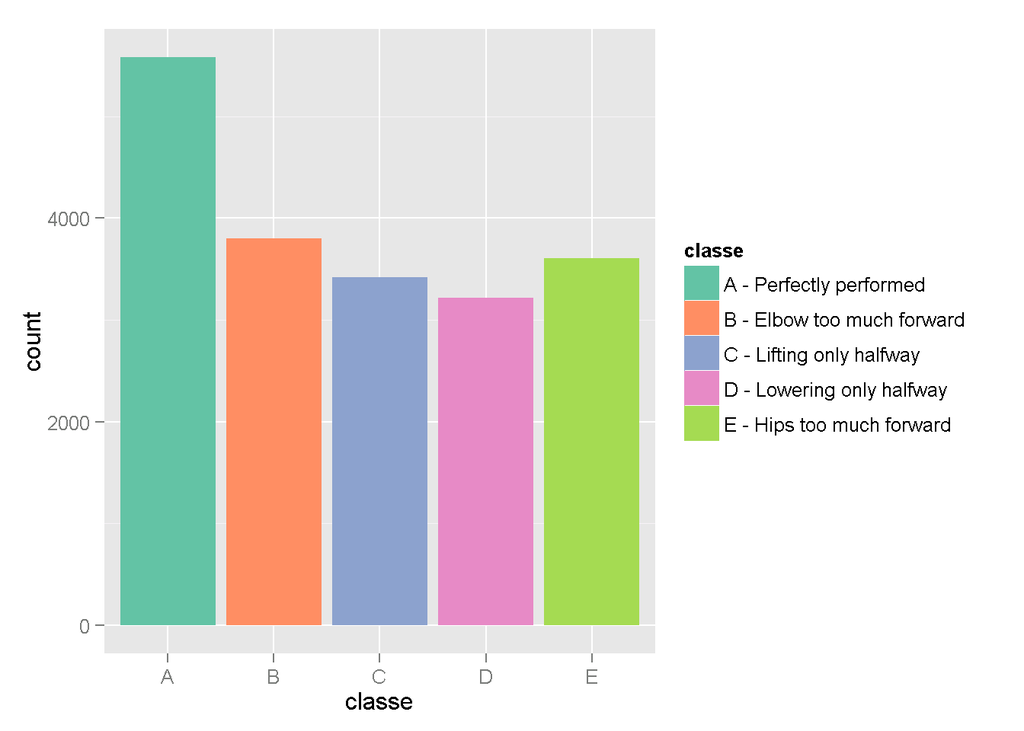

```r
q <- qplot(classe, data=train, xlab="classe", fill=classe)
q <- q + scale_fill_brewer(palette="Set2",
                           name="classe",
                           labels=c("A - Perfectly performed",
                                    "B - Elbow too much forward",
                                    "C - Lifting only halfway",
                                    "D - Lowering only halfway",
                                    "E - Hips too much forward")
                      )
print(q)
```

Although A is dominant, the number of each error type B-E is high enough not to require any weighting.

## Confusion matrix for the final model

```r
confFinal
```

```
## Confusion Matrix and Statistics
##
##           Reference
## Prediction    A    B    C    D    E
##          A 1112    5    0    0    0
##          B    1  752    3    0    0
##          C    2    2  676    4    3
##          D    0    0    5  639    1
##          E    1    0    0    0  717
##
## Overall Statistics
##
##                Accuracy : 0.9931
##                  95% CI : (0.99, 0.9955)
##     No Information Rate : 0.2845
##     P-Value [Acc > NIR] : < 2.2e-16
##
##                   Kappa : 0.9913
##  Mcnemar's Test P-Value : NA
##
## Statistics by Class:
##
##                      Class: A Class: B Class: C Class: D Class: E
## Sensitivity            0.9964   0.9908   0.9883   0.9938   0.9945
## Specificity            0.9982   0.9987   0.9966   0.9982   0.9997
## Pos Pred Value         0.9955   0.9947   0.9840   0.9907   0.9986
## Neg Pred Value         0.9986   0.9978   0.9975   0.9988   0.9988
## Prevalence             0.2845   0.1935   0.1744   0.1639   0.1838
## Detection Rate         0.2835   0.1917   0.1723   0.1629   0.1828
## Detection Prevalence   0.2847   0.1927   0.1751   0.1644   0.1830
## Balanced Accuracy      0.9973   0.9948   0.9925   0.9960   0.9971
```